# CITS4009 Project 1: 2021

Amal Seby Chirackal (22829076)

# Introduction

# Exploratory study of data

In order to exploration of data, firstly required libraries and data set is loaded.

```r
#load libraries
library(dplyr)
library(ggplot2)
#load data set in R environment
us_data <- read.csv("us_data.csv")
```

# Using R functions to explore the data

```r
#structure of the data set
str(us_data)
```

```
'data.frame':   202814 obs. of  57 variables:
 $ MINE_ID            : int  100003 100003 100008 100011 100011 100011 100011 100011 100016 100021 ...
 $ CONTROLLER_ID      : chr  "41044" "41044" "M31753" "M11763" ...
 $ CONTROLLER_NAME    : chr  "Lhoist Group" "Lhoist Group" "Alan B  Cheney" "Imerys S A" ...
 $ OPERATOR_ID        : chr  "L13586" "L13586" "L31753" "L17074" ...
 $ OPERATOR_NAME      : chr  "Lhoist North America " "Lhoist North America " "Cheney Lime & Cement Company" "Imerys Pigments LLC" ...
 $ CONTRACTOR_ID      : chr  "" "" "" "" ...
 $ DOCUMENT_NO        : num  2.2e+11 2.2e+11 2.2e+11 2.2e+11 2.2e+11 ...
 $ SUBUNIT_CD         : int  3 30 30 30 30 30 30 30 3 3 ...
 $ SUBUNIT            : chr  "STRIP, QUARY, OPEN PIT" "MILL OPERATION/PREPARATION PLANT" "MILL OPERATION/PREPARATION PLANT" "MILL OPERATION/PREPARATION PLANT" ...
 $ ACCIDENT_DT        : chr  "14/03/2012" "8/01/2007" "4/07/2009" "26/05/2000" ...
 $ CAL_YR             : int  2012 2007 2009 2000 2005 2006 2008 2012 2000 2006 ...
 $ CAL_QTR            : int  1 1 3 2 1 1 4 2 3 1 ...
 $ FISCAL_YR          : int  2012 2007 2009 2000 2005 2006 2009 2012 2000 2006 ...
 $ FISCAL_QTR         : int  2 2 4 3 2 2 1 3 4 2 ...
```

[output cut: 43 more lines]

Data set contain 57 attributes with 202814 instances. 13 integer, 5 numeric and 39 character variables.

```r
#summary of the data set
summary(us_data)
```

```
    MINE_ID        CONTROLLER_ID      CONTROLLER_NAME    OPERATOR_ID        OPERATOR_NAME
 Min.   : 100003   Length:202814      Length:202814      Length:202814      Length:202814
 1st Qu.:1300095   Class :character   Class :character   Class :character   Class :character
 Median :2602512   Mode  :character   Mode  :character   Mode  :character   Mode  :character
 Mean   :2684336
 3rd Qu.:4400170
 Max.   :5500008

 CONTRACTOR_ID       DOCUMENT_NO          SUBUNIT_CD       SUBUNIT          ACCIDENT_DT            CAL_YR
 Length:202814      Min.   :2.200e+11   Min.   : 1.000   Length:202814      Length:202814      Min.   :2000
 Class :character   1st Qu.:2.200e+11   1st Qu.: 1.000   Class :character   Class :character   1st Qu.:2002
 Mode  :character   Median :2.201e+11   Median : 3.000   Mode  :character   Mode  :character   Median :2006
                    Mean   :2.201e+11   Mean   : 9.362                                         Mean   :2006
                    3rd Qu.:2.201e+11   3rd Qu.:17.000                                         3rd Qu.:2010
                    Max.   :2.202e+11   Max.   :99.000                                         Max.   :2015

    CAL_QTR        FISCAL_YR      FISCAL_QTR    ACCIDENT_TIME  DEGREE_INJURY_CD   DEGREE_INJURY
 Min.   :1.000   Min.   :2000   Min.   :1.000   Min.   :   1   Length:202814      Length:202814
 1st Qu.:1.000   1st Qu.:2003   1st Qu.:2.000   1st Qu.: 845   Class :character   Class :character
 Median :2.000   Median :2006   Median :3.000   Median :1230   Mode  :character   Mode  :character
 Mean   :2.453   Mean   :2006   Mean   :2.574   Mean   :1886
 3rd Qu.:3.000   3rd Qu.:2010   3rd Qu.:4.000   3rd Qu.:1730
 Max.   :4.000   Max.   :2015   Max.   :4.000   Max.   :9999
                                                NA's   :1
 FIPS_STATE_CD   UG_LOCATION_CD     UG_LOCATION        UG_MINING_METHOD_CD UG_MINING_METHOD
 Min.   : 1.00   Length:202814      Length:202814      Length:202814       Length:202814
 1st Qu.:18.00   Class :character   Class :character   Class :character    Class :character
 Median :32.00   Mode  :character   Mode  :character   Mode  :character    Mode  :character
 Mean   :32.31
 3rd Qu.:49.00
 Max.   :78.00

 MINING_EQUIP_CD    MINING_EQUIP       EQUIP_MFR_CD       EQUIP_MFR_NAME     EQUIP_MODEL_NO
 Length:202814      Length:202814      Length:202814      Length:202814      Length:202814
 Class :character   Class :character   Class :character   Class :character   Class :character
 Mode  :character   Mode  :character   Mode  :character   Mode  :character   Mode  :character




```

[output cut: 33 more lines]

```
 Min.   :   0.00   Length:202814      Length:202814      Length:202814      Length:202814
 1st Qu.:   0.00   Class :character   Class :character   Class :character   Class :character
 Median :   0.00   Mode  :character   Mode  :character   Mode  :character   Mode  :character
 Mean   :  25.26
 3rd Qu.:  21.00
 Max.   :1247.00
 NA's   :39677
 INVEST_BEGIN_DT     NARRATIVE         CLOSED_DOC_NO       COAL_METAL_IND
 Length:202814      Length:202814      Min.   :3.200e+10   Length:202814
 Class :character   Class :character   1st Qu.:3.200e+11   Class :character
 Mode  :character   Mode  :character   Median :3.201e+11   Mode  :character
                                       Mean   :3.201e+11
                                       3rd Qu.:3.201e+11
                                       Max.   :3.202e+11
                                       NA's   :116621
```

First 5 rows of the data set to have glance of the data are bellow:

```r
head(us_data,5)
```

|  | MINE_ID | CONTROLLER_ID | CONTROLLER_NAME | OPERATOR_ID | OPERATOR_NAME | CONTRACTOR_ID | DOCUMENT_NO | SUBUNIT_CD | SUBUNIT | ACCIDENT_DT | CAL_YR | CAL_QTR | FISCAL_YR | FISCAL_QTR | ACCIDENT_TIME | DEGREE_INJURY_CD | DEGREE_INJURY | FIPS_STATE_CD | UG_LOCATION_CD | UG_LOCATION | UG_MINING_METHOD_CD | UG_MINING_METHOD | MINING_EQUIP_CD | MINING_EQUIP | EQUIP_MFR_CD | EQUIP_MFR_NAME | EQUIP_MODEL_NO | SHIFT_BEGIN_TIME | CLASSIFICATION_CD | … |
| --- | --- | --- | --- | --- | --- | --- | --- | --- | --- | --- | --- | --- | --- | --- | --- | --- | --- | --- | --- | --- | --- | --- | --- | --- | --- | --- | --- | --- | --- | --- |
| 1 | 100003 | 41044 | Lhoist Group | L13586 | Lhoist North America |  | 2.20121e+11 | 3 | STRIP, QUARY, OPEN PIT | 14/03/2012 | 2012 | 1 | 2012 | 2 | 945 | 5 | DAYS RESTRICTED ACTIVITY ONLY | 1 | ? | NO VALUE FOUND | ? | NO VALUE FOUND | 24 | Front-end loader, Tractor-shovel, Payloader, Highlift, Skip loader | 119 | Not on this list | 22321 | 600 | 12 | … |
| 2 | 100003 | 41044 | Lhoist Group | L13586 | Lhoist North America |  | 2.20070e+11 | 30 | MILL OPERATION/PREPARATION PLANT | 8/01/2007 | 2007 | 1 | 2007 | 2 | 1105 | 6 | NO DYS AWY FRM WRK,NO RSTR ACT | 1 | ? | NO VALUE FOUND | ? | NO VALUE FOUND | 28 | Hand tools (not powered) | 121 | Not Reported |  | 700 | 10 | … |
| 3 | 100008 | M31753 | Alan B Cheney | L31753 | Cheney Lime & Cement Company |  | 2.20092e+11 | 30 | MILL OPERATION/PREPARATION PLANT | 4/07/2009 | 2009 | 3 | 2009 | 4 | 1000 | 3 | DAYS AWAY FROM WORK ONLY | 1 | ? | NO VALUE FOUND | ? | NO VALUE FOUND | ? | NO VALUE FOUND | ? | NO VALUE FOUND |  | 600 | 18 | … |
| 4 | 100011 | M11763 | Imerys S A | L17074 | Imerys Pigments LLC |  | 2.20004e+11 | 30 | MILL OPERATION/PREPARATION PLANT | 26/05/2000 | 2000 | 2 | 2000 | 3 | 1100 | 5 | DAYS RESTRICTED ACTIVITY ONLY | 1 | ? | NO VALUE FOUND | ? | NO VALUE FOUND | ? | NO VALUE FOUND | ? | NO VALUE FOUND | ? | 700 | 9 | … |
| 5 | 100011 | M11763 | Imerys S A | L17074 | Imerys Pigments LLC |  | 2.20050e+11 | 30 | MILL OPERATION/PREPARATION PLANT | 22/01/2005 | 2005 | 1 | 2005 | 2 | 1430 | 5 | DAYS RESTRICTED ACTIVITY ONLY | 1 | ? | NO VALUE FOUND | ? | NO VALUE FOUND | ? | NO VALUE FOUND | ? | NO VALUE FOUND |  | 700 | 9 | … |

# Data cleaning

## Dealing with NA values

Checking for missing values in each column of data set

```r
sapply(us_data,function(x)sum(is.na(x)))
```

```
            MINE_ID       CONTROLLER_ID     CONTROLLER_NAME         OPERATOR_ID       OPERATOR_NAME
                  0                   0                   0                   0                   0
      CONTRACTOR_ID         DOCUMENT_NO          SUBUNIT_CD             SUBUNIT         ACCIDENT_DT
                  0                   0                   0                   0                   0
             CAL_YR             CAL_QTR           FISCAL_YR          FISCAL_QTR       ACCIDENT_TIME
                  0                   0                   0                   0                   1
   DEGREE_INJURY_CD       DEGREE_INJURY       FIPS_STATE_CD      UG_LOCATION_CD         UG_LOCATION
                  0                   0                   0                   0                   0
UG_MINING_METHOD_CD    UG_MINING_METHOD     MINING_EQUIP_CD        MINING_EQUIP        EQUIP_MFR_CD
                  0                   0                   0                   0                   0
     EQUIP_MFR_NAME      EQUIP_MODEL_NO    SHIFT_BEGIN_TIME   CLASSIFICATION_CD      CLASSIFICATION
                  0                  48                 991                   0                   0
   ACCIDENT_TYPE_CD       ACCIDENT_TYPE         NO_INJURIES           TOT_EXPER          MINE_EXPER
                  0                   0                   0               37400               34325
          JOB_EXPER       OCCUPATION_CD          OCCUPATION         ACTIVITY_CD            ACTIVITY
              33746                   0                   0                   0                   0
   INJURY_SOURCE_CD       INJURY_SOURCE    NATURE_INJURY_CD       NATURE_INJURY    INJ_BODY_PART_CD
                  0                   0                   0                   0                   0
      INJ_BODY_PART     SCHEDULE_CHARGE       DAYS_RESTRICT           DAYS_LOST          TRANS_TERM
                  0               65006               54856               39677                   0
  RETURN_TO_WORK_DT     IMMED_NOTIFY_CD        IMMED_NOTIFY     INVEST_BEGIN_DT           NARRATIVE
                  0                   0                   0                   0                   0
      CLOSED_DOC_NO      COAL_METAL_IND
             116621                   0
```

## Dealing with Anamolies

checking for outliers in the data.

```r
par(mfrow = c(2, 2))
boxplot(us_data$SUBUNIT_CD, main= "SUBUNIT_CD")
boxplot(us_data$ACCIDENT_TIME, main= "ACCIDENT_TIME")
```

```r
boxplot(us_data$SHIFT_BEGIN_TIME, main= "SHIFT_BEGIN_TIME")
boxplot(us_data$NO_INJURIES, main= "NO_INJURIES")
```

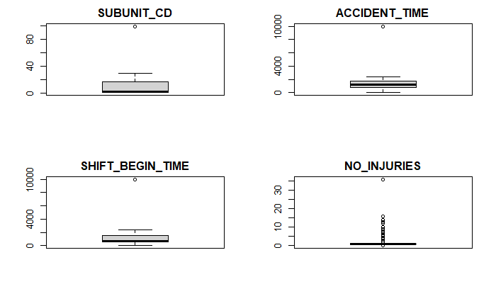

```r
par(mfrow = c(2, 2))
```

```r
barplot(us_data$TOT_EXPER, main= "TOT_EXPER")
barplot(us_data$MINE_EXPER, main= "MINE_EXPER")
```

```r
barplot(us_data$JOB_EXPER, main= "JOB_EXPER")
boxplot(us_data$SCHEDULE_CHARGE, main= "SCHEDULE_CHARGE")
```

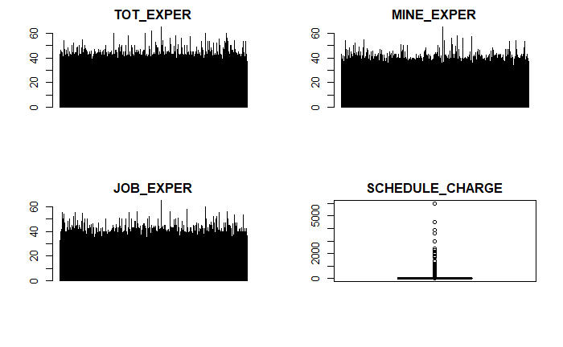

```r
par(mfrow = c(2, 2))
```

```r
hist(us_data$DAYS_RESTRICT, main= "DAYS_RESTRICT")
hist(us_data$DAYS_LOST, main= "DAYS_LOST")
```

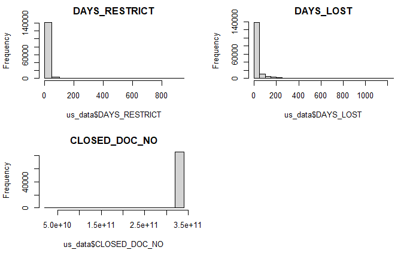

```r
hist(us_data$CLOSED_DOC_NO, main= "CLOSED_DOC_NO")
```

SUBUNIT_CD, ACCIDENT_TIME, SHIFT_BEGIN_TIME, NO_INJURIES, TOT_EXPER, MINE_EXPER, JOB_EXPER, SCHEDULE_CHARGE, DAYS_RESTRICT, DAYS_LOST and CLOSED_DOC_NO have outliers.

```r
#replacing outliers with missing values
for (i in c(8,15,28,33,34,35,36,47,48,49,56)){
     qntile <- quantile(us_data[,i], probs=c(.25, .75),na.rm = TRUE)
     H <- 1.5 * IQR(us_data[,i], na.rm = T)
     us_data[,i][us_data[,i] < (qntile[1] - H)] <- NA
     us_data[,i][us_data[,i] > (qntile[2] + H)] <- NA
}
```

```r
#replacing "?"
us_data$MINING_EQUIP_CD[us_data$MINING_EQUIP_CD == "?"] <- NA
us_data$EQUIP_MFR_CD[us_data$EQUIP_MFR_CD == "?"] <- NA
```

```r
#removing NA values
us_data <- na.omit(us_data)
```

## Data transformation

```r
#transform character type variables to factor type
us_data[sapply(us_data, is.character)] <- lapply(us_data[sapply(us_data, is.character)], as.factor)
```

## Visualization

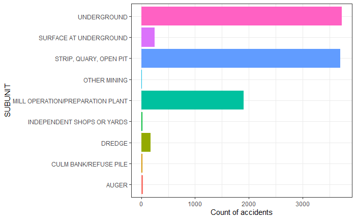

```r
# location within a mine where the accident/injury/illness occurred
ggplot(data = us_data,aes(SUBUNIT,fill=SUBUNIT )) +geom_bar() + coord_flip() +theme_bw() +
  theme(legend.position = "none") +ylab("Count of accidents")
```

underground,strip and open pit locations have more number of accidents as compare to other locations.

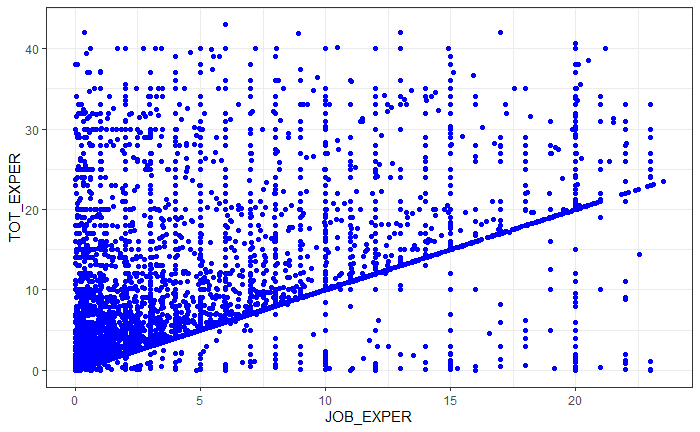

```r
#Relation of total mining experience of person with Experience in the job title of the person
ggplot(data = us_data,aes(JOB_EXPER,TOT_EXPER)) + geom_point(col= "blue") +
  theme_bw()
```

Their is a quite vague relation between JOB_EXPER & TOT_EXPE, but most of the employees have more Experience in the job title with more total mining experience.

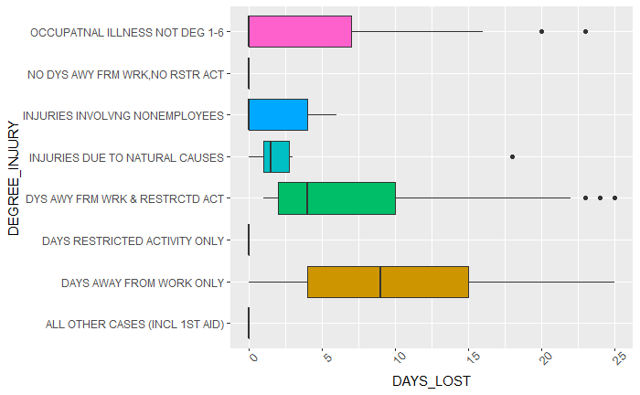

```r
#Actual days lost from work due to the injury/illness
ggplot(data = us_data,aes(DEGREE_INJURY,DAYS_LOST,fill= DEGREE_INJURY)) + geom_boxplot() +
  theme(axis.text.x = element_text(angle=45), legend.position = "none") +
  ylim(0,25) +coord_flip()
```

Degree of injury named Days away from work only has more Days lost.

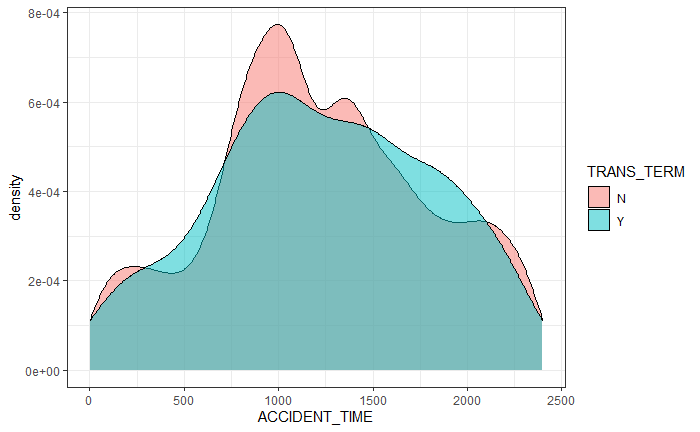

```r
#Distribution of accident time for employees who are terminated or not
ggplot(data = us_data,aes(ACCIDENT_TIME, fill= TRANS_TERM)) +
  geom_density(alpha= 0.5) +theme_bw()
```

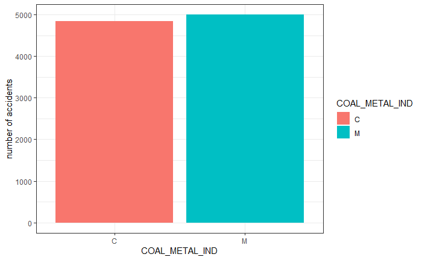

```r
# Identifies if the accident occurred at a Coal or Metal/Non-Metal mine.
ggplot(data = us_data,aes(COAL_METAL_IND,fill= COAL_METAL_IND)) + geom_histogram(stat="count")+
  theme_bw() + ylab("number of accidents")
```

Metal/Non-Metal mines have slightly more accidents as compare to coal mines.

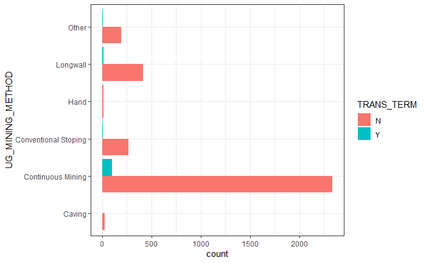

```r
#Minning method using which employees face accident and are permanently transferred or terminated
us_data %>% filter(UG_MINING_METHOD != "NO VALUE FOUND") %>%
  ggplot(aes(UG_MINING_METHOD,fill= TRANS_TERM)) +
  geom_histogram(stat="count",position = "dodge") + coord_flip()+
  theme_bw()
```

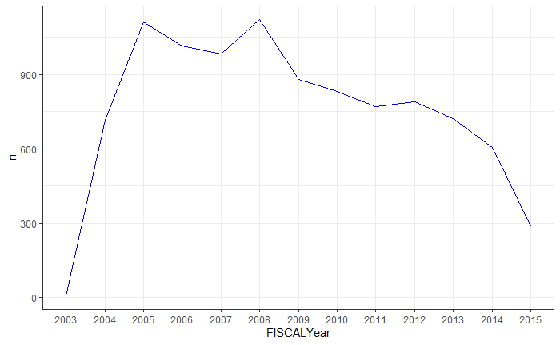

```r
#number of accidents/illness in each year
us_data  %>% group_by(FISCAL_YR) %>% count() %>%
  ggplot(aes(as.factor(FISCAL_YR),n)) + geom_line(col= "blue",group=1) +
  theme_bw() + xlab("FISCALYear")
```

2005 and 2008 have more cases of accidents and illness as compare to other years.

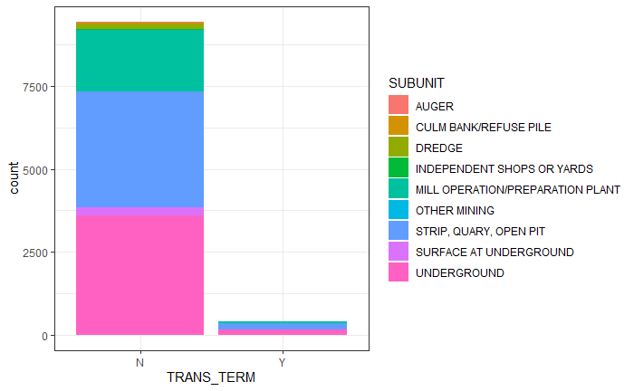

```r
#number of employees transferred/terminated,  working in sub units who faced accidents
ggplot(data = us_data,aes(TRANS_TERM,fill=SUBUNIT)) +geom_bar()+
  theme_bw()
```

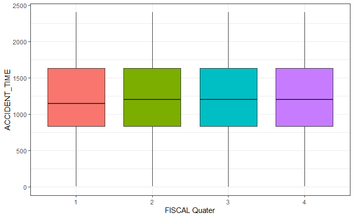

```r
ggplot(data = us_data ,aes(as.factor(FISCAL_QTR),ACCIDENT_TIME,fill=as.factor(FISCAL_QTR))) +
  geom_boxplot() + theme_bw() + theme( legend.position = "none") + xlab("FISCAL Quater")
```

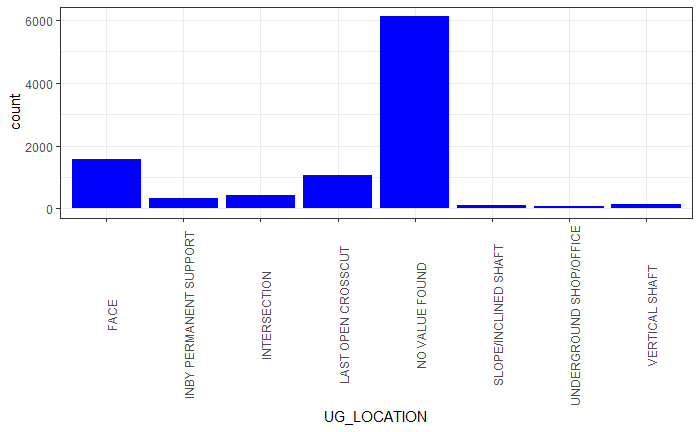

```r
ggplot(data = us_data,aes(UG_LOCATION)) + geom_histogram(fill="blue",stat="count")  +
  theme_bw() +
  theme(axis.text.x = element_text(angle=90))
```

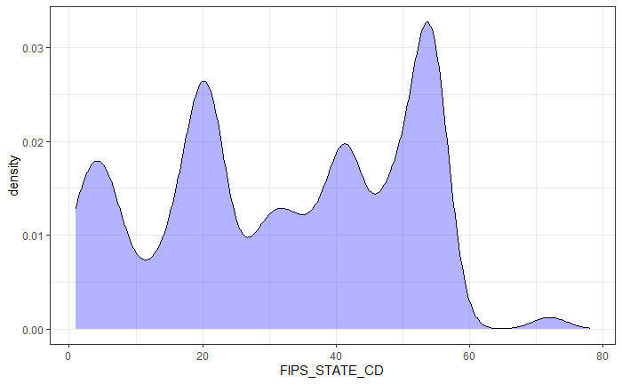

```r
ggplot(us_data,aes(FIPS_STATE_CD)) + geom_density(fill= "blue",alpha=0.3) +theme_bw()
```

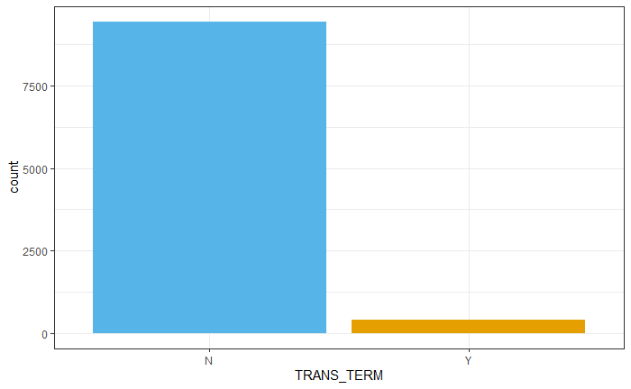

```r
ggplot(us_data,aes(TRANS_TERM,fill=TRANS_TERM)) + geom_bar()+
  scale_fill_manual(values=c("#56B4E9", "#E69F00")) +
   theme_bw() + theme( legend.position = "none")
```